# Analisis Kontribusi Pelanggan terhadap Pendapatan Rental Menggunakan Database Sakila

Nurkhafizh Tri Saputra

2026-05-25

# Pendahuluan

Perkembangan teknologi informasi telah membawa perubahan besar dalam berbagai sektor bisnis, termasuk industri hiburan dan layanan penyewaan digital. Di era modern, perusahaan tidak hanya berfokus pada penyediaan produk atau layanan, tetapi juga dituntut untuk mampu memahami perilaku pelanggan melalui pemanfaatan data. Data transaksi yang tersimpan dalam sistem perusahaan dapat menjadi sumber informasi penting untuk membantu proses pengambilan keputusan, meningkatkan kualitas layanan, serta menyusun strategi bisnis yang lebih efektif dan efisien. Oleh karena itu, analisis data menjadi salah satu aspek penting dalam dunia bisnis modern karena mampu memberikan insight yang berguna untuk memahami pola perilaku konsumen dan performa operasional perusahaan.

Salah satu bentuk implementasi analisis data dapat dilakukan melalui penggunaan database relasional. Database relasional memungkinkan data disimpan secara terstruktur dan saling terhubung antar tabel sehingga memudahkan proses pengolahan dan analisis data. Dalam pembelajaran database dan data analytics, salah satu database yang sering digunakan adalah database Sakila. Database Sakila merupakan database contoh yang dikembangkan oleh MySQL sebagai simulasi sistem rental film. Database ini memiliki berbagai tabel yang saling berhubungan, seperti tabel pelanggan, transaksi rental, pembayaran, film, kategori film, inventory, dan staff. Struktur data yang cukup lengkap menjadikan Sakila sangat cocok digunakan untuk latihan query SQL, eksplorasi data, visualisasi data, maupun analisis bisnis sederhana.

Melalui database Sakila, berbagai jenis analisis dapat dilakukan untuk memperoleh insight terkait aktivitas bisnis rental film. Salah satu analisis yang menarik untuk dilakukan adalah analisis kontribusi pelanggan terhadap pendapatan perusahaan. Dalam dunia bisnis, pelanggan memiliki peranan penting karena pendapatan perusahaan secara langsung bergantung pada aktivitas transaksi yang dilakukan oleh pelanggan. Namun demikian, tidak semua pelanggan memberikan kontribusi yang sama terhadap total pendapatan perusahaan. Sebagian pelanggan mungkin melakukan transaksi secara rutin dan menghasilkan pendapatan yang besar, sedangkan sebagian lainnya hanya melakukan transaksi dalam jumlah kecil atau tidak terlalu sering. Perbedaan perilaku pelanggan tersebut menjadi penting untuk dianalisis karena dapat membantu perusahaan dalam mengidentifikasi pelanggan potensial dan menyusun strategi pemasaran yang lebih tepat sasaran.

Analisis kontribusi pelanggan terhadap pendapatan juga berkaitan dengan konsep customer loyalty dan high value customer. Customer loyalty menggambarkan tingkat kesetiaan pelanggan terhadap suatu layanan, sedangkan high value customer merujuk pada pelanggan yang memberikan kontribusi pendapatan tinggi bagi perusahaan. Dalam praktik bisnis nyata, perusahaan sering kali menemukan bahwa sebagian kecil pelanggan mampu memberikan kontribusi besar terhadap total revenue. Fenomena ini dikenal sebagai Prinsip Pareto atau aturan 80/20, yaitu sekitar 20% pelanggan dapat menyumbang sekitar 80% pendapatan perusahaan. Oleh karena itu, identifikasi pelanggan bernilai tinggi menjadi salah satu langkah penting dalam strategi bisnis modern karena perusahaan dapat memfokuskan program promosi, peningkatan layanan, maupun strategi retensi pelanggan kepada kelompok pelanggan yang paling berkontribusi.

Pada laporan ini dilakukan analisis terhadap data pelanggan dan transaksi pada database Sakila untuk mengetahui kontribusi masing-masing pelanggan terhadap total pendapatan rental film. Analisis dilakukan dengan memanfaatkan query SQL untuk mengambil data yang relevan, kemudian data divisualisasikan menggunakan bahasa pemrograman R melalui R Markdown. Penggunaan R Markdown memungkinkan proses analisis, visualisasi, dan dokumentasi dilakukan dalam satu dokumen yang terintegrasi sehingga menghasilkan laporan yang lebih sistematis dan interaktif. Selain itu, laporan ini juga memanfaatkan kustomisasi HTML dan CSS untuk meningkatkan tampilan visual laporan agar lebih menarik dan profesional.

Melalui analisis ini diharapkan dapat diperoleh insight mengenai pola kontribusi pelanggan terhadap pendapatan rental film, mengetahui pelanggan dengan nilai transaksi tertinggi, serta memahami bagaimana distribusi pendapatan pelanggan dalam sistem rental. Hasil analisis tersebut dapat menjadi gambaran sederhana mengenai pentingnya data analytics dalam mendukung pengambilan keputusan bisnis berbasis data.

# Dataset

Dataset yang digunakan dalam laporan ini berasal dari database *Sakila*, yaitu database contoh yang dikembangkan oleh MySQL untuk mensimulasikan sistem bisnis rental film. Database ini dirancang untuk keperluan pembelajaran database relasional, query SQL, serta analisis data. Sakila memiliki struktur data yang cukup kompleks karena terdiri dari berbagai tabel yang saling berhubungan melalui relasi antar primary key dan foreign key.

Database Sakila menyimpan berbagai informasi terkait aktivitas bisnis rental film, seperti data pelanggan, data film, kategori film, transaksi rental, pembayaran, inventory, hingga data staff dan toko. Struktur tersebut memungkinkan pengguna untuk melakukan berbagai jenis analisis bisnis, mulai dari analisis pelanggan, performa film, pendapatan perusahaan, hingga pola transaksi rental.

Pada laporan ini tidak seluruh tabel digunakan dalam proses analisis. Analisis difokuskan pada insight mengenai kontribusi pelanggan terhadap total pendapatan rental sehingga hanya beberapa tabel yang relevan saja yang digunakan. Pemilihan tabel dilakukan untuk mempermudah proses pengolahan data dan menyesuaikan dengan tujuan analisis yang ingin dicapai.

## Tabel yang Digunakan

- **customer**  
  Tabel ini digunakan untuk memperoleh informasi pelanggan, seperti identitas customer yang melakukan transaksi rental.
- **rental**  
  Tabel rental digunakan untuk melihat aktivitas penyewaan film yang dilakukan oleh pelanggan. Tabel ini berisi informasi transaksi rental dan menjadi penghubung antara pelanggan dan pembayaran.
- **payment**  
  Tabel payment digunakan untuk memperoleh informasi jumlah pembayaran yang dilakukan pelanggan pada setiap transaksi rental. Data pada tabel ini digunakan untuk menghitung total pendapatan yang dihasilkan oleh masing-masing customer.

## Variabel yang Dianalisis

Beberapa variabel yang digunakan dalam analisis antara lain:

- **customer_name** → nama pelanggan
- **total_rental** → jumlah transaksi rental pelanggan
- **total_spending** → total pembayaran atau pengeluaran pelanggan

Variabel tersebut dipilih karena dapat menggambarkan tingkat aktivitas dan kontribusi masing-masing pelanggan terhadap pendapatan perusahaan rental film. Dengan menggunakan variabel tersebut, analisis dapat menunjukkan pelanggan yang memiliki nilai transaksi tinggi atau termasuk kategori *high value customer*.

Data hasil query kemudian diolah dan divisualisasikan menggunakan bahasa pemrograman R melalui R Markdown. Visualisasi dilakukan untuk mempermudah interpretasi data dan membantu dalam menemukan pola kontribusi pelanggan terhadap total pendapatan rental.

# Metode Analisis

Metode analisis yang digunakan dalam laporan ini adalah analisis deskriptif menggunakan data transaksi pada database Sakila. Analisis deskriptif dilakukan untuk memahami pola kontribusi pelanggan terhadap total pendapatan rental film berdasarkan jumlah transaksi dan total pembayaran yang dilakukan pelanggan.

Tahap pertama dalam proses analisis adalah pengambilan data menggunakan query SQL pada database MySQL. Query digunakan untuk menghubungkan beberapa tabel yang relevan, yaitu tabel *customer*, *rental*, dan *payment*. Proses penggabungan tabel dilakukan menggunakan operasi *JOIN* untuk memperoleh data pelanggan beserta jumlah transaksi rental dan total pembayaran yang dilakukan.

Data hasil query kemudian diolah menggunakan bahasa pemrograman R melalui R Markdown. Pengolahan data dilakukan untuk mempermudah proses visualisasi dan interpretasi hasil analisis. Selain itu, penggunaan R Markdown memungkinkan seluruh proses analisis, kode program, visualisasi, dan dokumentasi dapat disusun dalam satu laporan yang terintegrasi berbentuk HTML.

## Proses Analisis

Tahapan analisis yang dilakukan dalam laporan ini meliputi:

1. Menghubungkan database MySQL dengan R menggunakan package yang mendukung koneksi database.
2. Mengambil data pelanggan dan transaksi menggunakan query SQL.
3. Menghitung jumlah transaksi rental setiap pelanggan.
4. Menghitung total pengeluaran pelanggan berdasarkan data pembayaran.
5. Melakukan visualisasi data menggunakan grafik untuk melihat kontribusi pelanggan terhadap total pendapatan rental.
6. Menginterpretasikan hasil visualisasi untuk memperoleh insight bisnis.

## Perhitungan Total Pengeluaran

Total pengeluaran pelanggan dihitung berdasarkan penjumlahan seluruh pembayaran yang dilakukan pelanggan pada transaksi rental film. Secara matematis, total pengeluaran dapat dituliskan sebagai berikut:

$$\text{Total Spending} = \sum_{i=1}^{n} amount_i$$

Keterangan:

- **Total Spending** = total pembayaran pelanggan
- **amount** = nilai pembayaran pada setiap transaksi
- **n** = jumlah transaksi rental pelanggan

## Visualisasi Data

Visualisasi data dilakukan menggunakan package *ggplot2* pada bahasa pemrograman R. Jenis visualisasi yang digunakan adalah *horizontal bar chart* untuk menampilkan pelanggan dengan total pengeluaran tertinggi. Visualisasi ini dipilih karena mampu memperlihatkan perbedaan kontribusi antar pelanggan secara lebih jelas dan mudah dipahami.

Melalui metode analisis tersebut diharapkan dapat diperoleh insight mengenai pola kontribusi pelanggan terhadap pendapatan perusahaan rental film serta mengidentifikasi pelanggan yang memiliki kontribusi terbesar terhadap total revenue.

# Query SQL

Pengambilan data dilakukan menggunakan query SQL pada database Sakila. Query digunakan untuk menghubungkan tabel customer, rental, dan payment guna memperoleh informasi mengenai jumlah transaksi rental serta total pengeluaran masing-masing pelanggan.

## Koneksi Database

```
library(DBI)
library(odbc)
con <- DBI::dbConnect(odbc::odbc(),
                      Driver = "MySQL ODBC 8.0 ANSI Driver",
                      Server = "127.0.0.1",
                      UID = "root",
                      Port = 3306,
                      database = "sakila"))
```

Kode di atas digunakan untuk membuat koneksi antara R dan database MySQL sehingga data pada database Sakila dapat diakses dan dianalisis menggunakan R Markdown.

## Query Pengambilan Data

```
SELECT
    CONCAT(c.first_name, ' ', c.last_name) AS customer_name,
    COUNT(r.rental_id) AS total_rental,
    SUM(p.amount) AS total_spending
FROM customer c
JOIN rental r
    ON c.customer_id = r.customer_id
JOIN payment p
    ON r.rental_id = p.rental_id
GROUP BY c.customer_id, customer_name
ORDER BY total_spending DESC
LIMIT 10;
```

Query tersebut digunakan untuk menampilkan 10 pelanggan dengan total pengeluaran terbesar berdasarkan transaksi rental film pada database Sakila.

```
##     customer_name total_rental total_spending
## 1       KARL SEAL           45         221.55
## 2    ELEANOR HUNT           46         216.54
## 3      CLARA SHAW           42         195.58
## 4  RHONDA KENNEDY           39         194.61
## 5   MARION SNYDER           39         194.61
## 6   TOMMY COLLAZO           38         186.62
## 7     WESLEY BULL           40         177.60
## 8        TIM CARY           39         175.61
## 9     MARCIA DEAN           42         175.58
## 10    ANA BRADLEY           34         174.66
```

## Penjelasan Query

- **SELECT** digunakan untuk memilih data yang akan ditampilkan, yaitu nama pelanggan, jumlah transaksi rental, dan total pembayaran.
- **CONCAT()** digunakan untuk menggabungkan nama depan dan nama belakang pelanggan menjadi satu kolom.
- **COUNT()** digunakan untuk menghitung jumlah transaksi rental setiap pelanggan.
- **SUM()** digunakan untuk menghitung total pengeluaran pelanggan.
- **JOIN** digunakan untuk menghubungkan tabel customer, rental, dan payment berdasarkan relasi antar tabel.
- **GROUP BY** digunakan untuk mengelompokkan data berdasarkan pelanggan.
- **ORDER BY** digunakan untuk mengurutkan data berdasarkan total pengeluaran tertinggi.
- **LIMIT 10** digunakan untuk membatasi hasil query hanya pada 10 pelanggan teratas.

Hasil query kemudian digunakan sebagai dasar visualisasi dan analisis untuk melihat kontribusi pelanggan terhadap total pendapatan rental film.

# Visualisasi Data

Visualisasi data dilakukan untuk mempermudah proses interpretasi hasil analisis serta membantu dalam memahami pola kontribusi pelanggan terhadap total pendapatan rental film. Dengan visualisasi, data yang awalnya berbentuk tabel dapat disajikan dalam bentuk grafik yang lebih informatif dan mudah dipahami.

Pada laporan ini digunakan visualisasi berupa *horizontal bar chart* untuk menampilkan pelanggan dengan total pengeluaran tertinggi berdasarkan data transaksi rental pada database Sakila. Visualisasi dipilih dalam bentuk horizontal karena nama pelanggan cenderung lebih panjang sehingga lebih mudah dibaca dibandingkan menggunakan grafik batang vertikal.

Berikut merupakan syntax R yang digunakan untuk membuat visualisasi data menggunakan package *ggplot2*.

```
library(ggplot2)

ggplot(data_customer, aes(
  x = reorder(customer_name, total_spending),
  y = total_spending
)) +

  geom_col(fill = "#1F3C88") +

  coord_flip() +

  labs(
    title = "Top 10 Customer Berdasarkan Total Spending",
    subtitle = "Database Sakila",
    x = "Nama Customer",
    y = "Total Spending"
  ) +

  theme_minimal() +

  theme(
    plot.title = element_text(
      size = 18,
      face = "bold"
    ),

    plot.subtitle = element_text(
      size = 12,
      color = "gray40"
    ),

    axis.title = element_text(
      size = 12,
      face = "bold"
    ),

    axis.text = element_text(
      size = 10
    )
  )
```

Syntax tersebut digunakan untuk membuat grafik batang horizontal yang menampilkan pelanggan dengan total spending tertinggi. Fungsi *ggplot()* digunakan untuk membangun visualisasi, sedangkan *geom_col()* digunakan untuk membuat batang grafik berdasarkan total pengeluaran pelanggan.

Fungsi *coord_flip()* digunakan untuk mengubah grafik menjadi horizontal agar nama pelanggan lebih mudah dibaca. Selain itu, dilakukan juga kustomisasi tampilan grafik menggunakan *theme()* dan *theme_minimal()* agar visualisasi terlihat lebih rapi dan profesional.

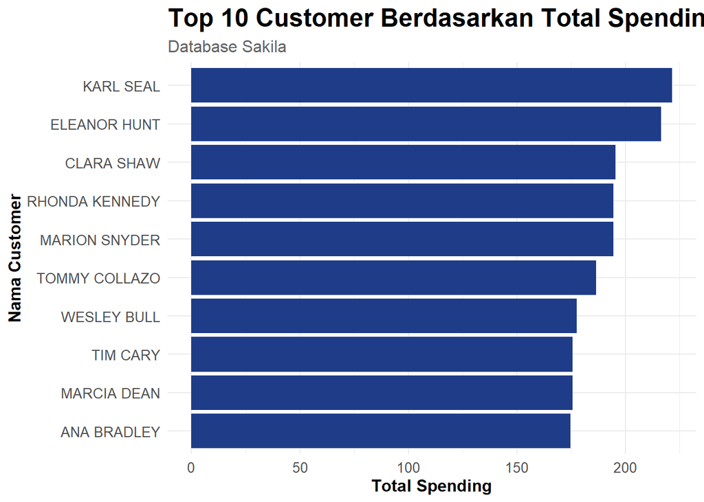

Grafik yang dihasilkan memperlihatkan perbandingan kontribusi pelanggan terhadap total pendapatan rental film. Semakin panjang batang pada grafik, maka semakin besar kontribusi pelanggan tersebut terhadap revenue perusahaan.

# Hasil dan Pembahasan

Hasil analisis ini menunjukkan bahwa data transaksi pelanggan dapat dimanfaatkan untuk membantu proses pengambilan keputusan bisnis. Perusahaan rental film dapat memanfaatkan informasi mengenai pelanggan bernilai tinggi untuk menyusun strategi bisnis yang lebih efektif, seperti pemberian promosi khusus, program loyalitas pelanggan, maupun peningkatan kualitas layanan bagi pelanggan aktif.

Selain itu, analisis ini juga memperlihatkan pentingnya penggunaan data analytics dalam memahami perilaku pelanggan. Dengan melakukan analisis terhadap pola transaksi dan pengeluaran pelanggan, perusahaan dapat mengidentifikasi karakteristik pelanggan yang paling berkontribusi terhadap pendapatan sehingga strategi bisnis dapat dilakukan secara lebih terarah dan berbasis data.

Secara keseluruhan, hasil visualisasi menunjukkan bahwa kontribusi pelanggan terhadap pendapatan rental bersifat tidak merata dan terdapat kelompok pelanggan tertentu yang memiliki kontribusi dominan terhadap total revenue perusahaan rental film.

# Kesimpulan

Analisis ini juga menunjukkan bahwa data transaksi pelanggan dapat dimanfaatkan untuk memahami pola perilaku customer dan membantu proses pengambilan keputusan bisnis. Informasi mengenai pelanggan dengan kontribusi terbesar dapat digunakan perusahaan untuk menyusun strategi pemasaran, meningkatkan loyalitas pelanggan, serta mengembangkan program promosi yang lebih tepat sasaran.

Selain memberikan insight bisnis, laporan ini juga menunjukkan penerapan analisis data menggunakan database relasional, query SQL, visualisasi data menggunakan R, serta penyusunan laporan interaktif menggunakan R Markdown berbasis HTML dan CSS. Dengan demikian, analisis yang dilakukan tidak hanya membantu memahami data transaksi rental film, tetapi juga menunjukkan pentingnya pemanfaatan data analytics dalam mendukung strategi bisnis berbasis data.